# Mestrado - dados 2018

Gabriela Galvão

# CALENDÁRIO ESPERADO

**16/08** - Envio das análises  
**20/08** - Fim das análises corrigidas  
**31/08** - Envio da parte escrita  
**18/09** - Fim da parte escrita corrigida  
**24/09** - Apresentação do artigo  
**30/09** - Seminários 2

# INFORMAÇÕES

### Título:

Efeito da estrutura de paisagem sobre o potencial de recuperação de áreas degradadas

### Pergunta 1:

**Qual a sindrome funcional que prevalece?**  
**H1** As áreas submetidas à restauração possuem uma síndrome funcional da comunidade relacionada a espécies ruderais, com poucas especializações e sementes mais leves

### Pergunta 2:

**Como essas sindromes variam em funcao da condincao da paisagem?**  
**H2**areas com maior cobertura vegetal possuem maior diversidade funcional, compreendendo uma sindrome funcional de atributos de plantas relacionados a especies mais especialista.  
**H3**Áreas com maior densidade de manchas possuem menor diversidade funcional, compreendendo uma síndrome funcional de atributos de plantas relacionados à espécies mais generalistas.  
**H4**Áreas com maior cobertura vegetal possuem maior diversidade filogenética no banco de sementes.  
**H5**Áreas com maior densidade de manchas possuem menor diversidade filogenética no banco de sementes.

# PACOTES

```r
library(FD)
library(tidyverse)
library(lme4)
library(ade4)
library(gridExtra)
library(ggplot2)
library(ggrepel)
library(picante)
library(vegan)
library(SYNCSA)
library(GGally)
library(betapart)
library(nlme)
library(ape)
library(TPD)
library(cati)
library(kableExtra)
library(phytools)
library(geiger)
library(knitr)
library(rmarkdown)
```

# DADOS

```r
traits<-read.csv("traits_2018.csv", h=T, ";", row.names = 1)
comunidade <- read.csv("comunidade2018.csv", h=T, ";", row.names=1)
cmm<-comunidade[,20:89]
tree <- read.tree("tree2018.tre")
```

# DIVERSIDADE FUNCIONAL

## padronização dos dados

```r
traits %>%
  dplyr::summarise_all(class) %>%
  tidyr::gather(variable, class)
```

```
##               variable     class
## 1                h_max   integer
## 2                h_min   integer
## 3             leaf_min   integer
## 4             leaf_max   integer
## 5              semente   numeric
## 6            dispersal character
## 7            life_span character
## 8                 type character
## 9     Floral_rewarning character
## 10 Pollination_systems character
## 11           leaf_tipe character
## 12           filotaxia character
## 13             nativas character
```

```r
traits$h_max <- as.ordered(traits$h_max)
traits$h_min <- as.ordered(traits$h_min)
traits$leaf_min<- as.ordered(traits$leaf_min)
traits$leaf_max<- as.ordered(traits$leaf_max)
traits$semente<- as.ordered(traits$semente)

traits_categ <- cbind.data.frame(dispersal=traits$dispersal, life_span=traits$life_span, type=traits$type, floral_rewarning=traits$Floral_rewarning, Pollination=traits$Pollination_systems, leaf_type=traits$leaf_tipe,filotaxia=traits$filotaxia, nativas=traits$nativas)

traits_cont <- cbind.data.frame(altura_max=traits$h_max, altura_min=traits$h_min, tamanho_folha_max=traits$leaf_max, tamanho_folha_min=traits$leaf_min, peso_semente=traits$semente)

rownames(traits_categ) <- rownames(traits)
rownames(traits_cont) <- rownames(traits)
```

## Distância funcional entre as espécies

Em “type”, a letra “N” indica variável categórica (ou nominal), enquanto a letra “O” indica variável ordinal.

```r
ktab_list <- ktab.list.df(list(traits_categ, traits_cont))
dist_mist <- dist.ktab(ktab_list, type= c("N", "O"))
```

## PCoA

Visualizar os dados

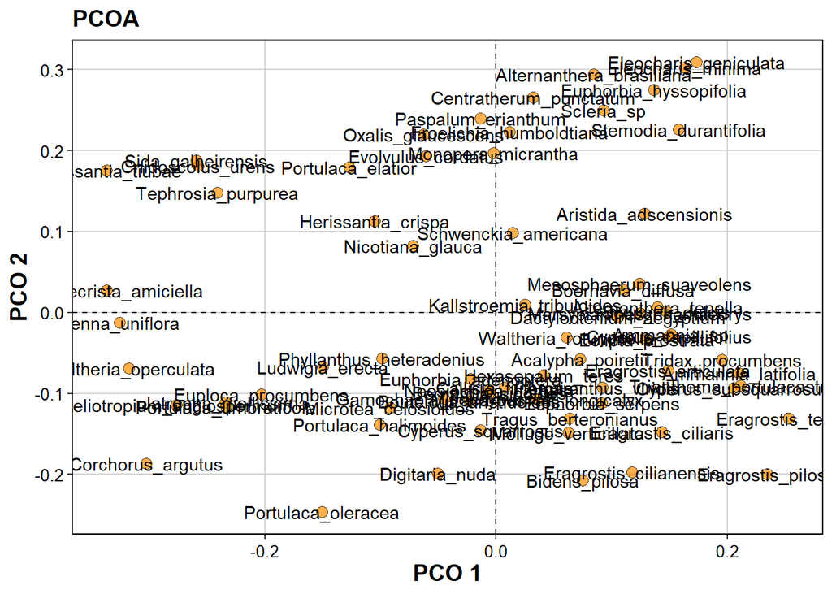

```r
pcoa_traits_mist <- pcoa(dist_mist, correction="cailliez")
eixos_mist <- as.data.frame(pcoa_traits_mist$vectors[,1:2])

eixos_mist %>%
  ggplot(aes(x=Axis.1, y=Axis.2)) +
  geom_point(pch=21, size=3, alpha = 0.7, color = "black", fill="darkorange") + geom_text(aes(label = rownames(eixos_mist)))+
  xlab("PCO 1") + ylab("PCO 2") +
  theme(axis.title.x = element_text(face="bold", size=14),
        axis.text.x = element_text(vjust=0.5, size=12)) +
  theme(axis.title.y = element_text(face="bold", size=14),
        axis.text.y = element_text(vjust=0.5, size=12)) +
  geom_hline(yintercept = 0, linetype=2) +
  geom_vline(xintercept = 0, linetype=2)+
  theme(legend.position = "top", legend.title=element_blank()) +
  tema_livro + ggtitle("PCOA") -> plot_trait_mist
plot_trait_mist
```

## Métricas funcionais

```r
richness <- dbFD(dist_mist, cmm,corr = c("cailliez"))$nbsp
```

```
## Species x species distance matrix was not Euclidean. Cailliez correction was applied.
## FRic: Dimensionality reduction was required. The last 62 PCoA axes (out of 68 in total) were removed.
## FRic: Quality of the reduced-space representation (based on corrected distance matrix) = 0.2310965
## CWM: When 'x' is a distance matrix, CWM cannot be calculated.
```

```r
fric <- dbFD(dist_mist, cmm, corr = c("cailliez"))$FRic
```

```
## Species x species distance matrix was not Euclidean. Cailliez correction was applied.
## FRic: Dimensionality reduction was required. The last 62 PCoA axes (out of 68 in total) were removed.
## FRic: Quality of the reduced-space representation (based on corrected distance matrix) = 0.2310965
## CWM: When 'x' is a distance matrix, CWM cannot be calculated.
```

```r
## Functional Diversity
# Passo 1: análise de agrupamento para criar o dendrograma.
dend <- hclust(dist_mist, "average")

# Passo 2: transformar o dengrograma em um arquivo da classe phylo.
tree_dend <-as.phylo(dend)

# Passo 3: calcular o valor da diversidade funcional.
FD <- pd(cmm, tree_dend)$PD
head(FD)
```

```
## [1] 2.838207 2.553956 4.132056 4.527988 5.234868 3.389996
```

```r
fdiv <- dbFD(dist_mist, cmm, corr = "cailliez")$FDiv
```

```
## Species x species distance matrix was not Euclidean. Cailliez correction was applied.
## FRic: Dimensionality reduction was required. The last 62 PCoA axes (out of 68 in total) were removed.
## FRic: Quality of the reduced-space representation (based on corrected distance matrix) = 0.2310965
## CWM: When 'x' is a distance matrix, CWM cannot be calculated.
```

```r
fdis <- dbFD(dist_mist, cmm, corr="cailliez")$FDis
```

```
## Species x species distance matrix was not Euclidean. Cailliez correction was applied.
## FRic: Dimensionality reduction was required. The last 62 PCoA axes (out of 68 in total) were removed.
## FRic: Quality of the reduced-space representation (based on corrected distance matrix) = 0.2310965
## CWM: When 'x' is a distance matrix, CWM cannot be calculated.
```

```r
feve <- dbFD(dist_mist, cmm, corr="cailliez")$FEve
```

```
## Species x species distance matrix was not Euclidean. Cailliez correction was applied.
## FRic: Dimensionality reduction was required. The last 62 PCoA axes (out of 68 in total) were removed.
## FRic: Quality of the reduced-space representation (based on corrected distance matrix) = 0.2310965
## CWM: When 'x' is a distance matrix, CWM cannot be calculated.
```

```r
metricas <- data.frame(richness=richness,
                       FD = FD,
                       fric = fric,
                       fdiv = fdiv,
                       fdis = fdis,
                       feve = feve)
head(metricas)
```

```
##      richness       FD         fric      fdiv      fdis      feve
## 3003       12 2.838207 0.0015129022 0.8906987 0.2989970 0.1958529
## 3008       10 2.553956 0.0006370813 0.8874265 0.3866155 0.6030700
## 3015       17 4.132056 0.0058096964 0.9121205 0.3393390 0.4922339
## 3016       18 4.527988 0.0142101401 0.8670804 0.4126126 0.4532576
## 3017       23 5.234868 0.0407875007 0.8142259 0.3064830 0.5111051
## 3018       13 3.389996 0.0027090448 0.9016592 0.2574118 0.3101070
```

## gráfico comparando as métricas

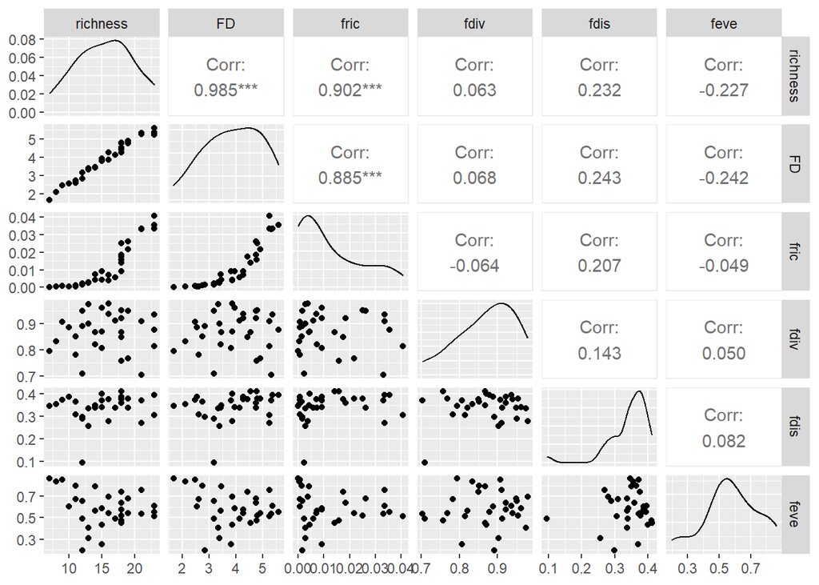

```r
ggpairs(metricas)
```

# Hipótese 1

```r
#composição funcional
composicao_funcional <- functcomp(x = traits, a = as.matrix(cmm), CWM.type = c("dom"))
```

*NÃO TO CONSEGUNDO FAZER A PERMANOVA

# ESCALA DE EFEITO

## Funcional:

*não é possível fazer com a riqueza funcional: não calcula AIC. função multifiti  
Pd: Densidade de manchas de floresta (por/hectare); medida de fragmentação da paisagem.  
NDV: Índice de Vegetação por Diferença Normalizada. Riqueza funcional (FRic)

```r
comunidade_multfit <- read.csv("comunidade2018.csv", h=T, ";")
comunidade_multfit_1 <- cbind(comunidade_multfit, richness=metricas$fric)
fits_ndv_1 <- multifit(mod="glmer", multief = colnames(comunidade_multfit_1[4:11]),
                     formula=richness~multief+(1|area), args=c("family=poisson"),data=comunidade_multfit_1,
                     criterion = "AIC", plot_est = T)
fits_ndv_1$models
```

```
## $ndv100
## Generalized linear mixed model fit by maximum likelihood (Laplace
##   Approximation) [glmerMod]
##  Family: poisson  ( log )
## Formula: richness ~ ndv100 + (1 | area)
##    Data: comunidade_multfit_1
##      AIC      BIC   logLik deviance df.resid
##      Inf      Inf     -Inf      Inf       29
## Random effects:
##  Groups Name        Std.Dev.
##  area   (Intercept) 1
## Number of obs: 32, groups:  area, 32
## Fixed Effects:
## (Intercept)       ndv100
##      -4.616       58.183
## optimizer (Nelder_Mead) convergence code: 0 (OK) ; 2240 optimizer warnings; 1 lme4 warnings
##
## $ndv140
## Generalized linear mixed model fit by maximum likelihood (Laplace
##   Approximation) [glmerMod]
##  Family: poisson  ( log )
## Formula: richness ~ ndv140 + (1 | area)
##    Data: comunidade_multfit_1
##      AIC      BIC   logLik deviance df.resid
##      Inf      Inf     -Inf      Inf       29
## Random effects:
##  Groups Name        Std.Dev.
##  area   (Intercept) 1
## Number of obs: 32, groups:  area, 32
## Fixed Effects:
## (Intercept)       ndv140
##      -4.608       45.432
## optimizer (Nelder_Mead) convergence code: 0 (OK) ; 2240 optimizer warnings; 1 lme4 warnings
##
## $ndv200
## Generalized linear mixed model fit by maximum likelihood (Laplace
##   Approximation) [glmerMod]
##  Family: poisson  ( log )
## Formula: richness ~ ndv200 + (1 | area)
##    Data: comunidade_multfit_1
```

[output cut: 80 more lines]

```
## Generalized linear mixed model fit by maximum likelihood (Laplace
##   Approximation) [glmerMod]
##  Family: poisson  ( log )
## Formula: richness ~ ndv1130 + (1 | area)
##    Data: comunidade_multfit_1
##      AIC      BIC   logLik deviance df.resid
##      Inf      Inf     -Inf      Inf       29
## Random effects:
##  Groups Name        Std.Dev.
##  area   (Intercept) 1
## Number of obs: 32, groups:  area, 32
## Fixed Effects:
## (Intercept)      ndv1130
##      -4.787       64.571
## optimizer (Nelder_Mead) convergence code: 0 (OK) ; 2240 optimizer warnings; 1 lme4 warnings
```

```
## The model including the effect 'ndv800' was the best model according to the specified criterion (AIC, which.min)
```

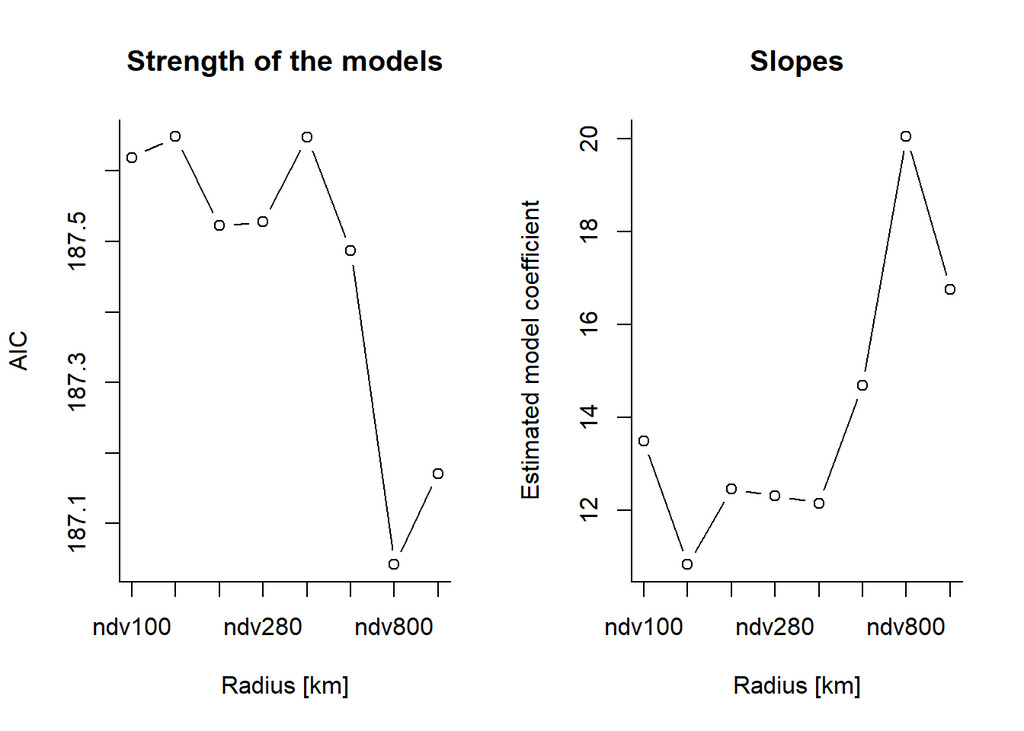

```r
comunidade_multfit <- read.csv("comunidade2018.csv", h=T, ";")
fits_ndv <- multifit(mod="glmer", multief = colnames(comunidade_multfit[4:11]),
                     formula=Riqueza~multief+(1|area), args=c("family=poisson"),data=comunidade_multfit,
                     criterion = "AIC", plot_est = T)
```

```
## The model including the effect 'pd140' was the best model according to the specified criterion (AIC, which.min)
```

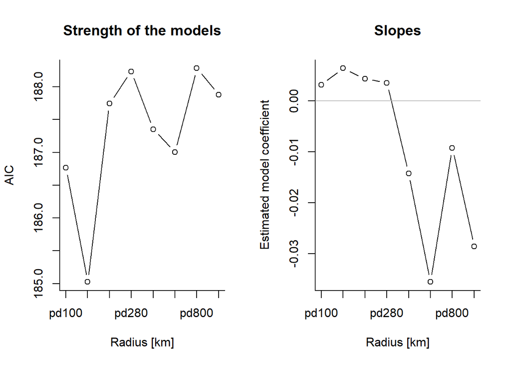

```r
fits_pd <- multifit(mod="glmer", multief = colnames(comunidade_multfit[12:19]),
                    formula=Riqueza~multief+(1|area), args=c("family=poisson"),data=comunidade_multfit,
                    criterion = "AIC", plot_est = T)
```

Melhores modelos: ndv800 / pd140

# DIVERSIDADE FILOGENÉTICA

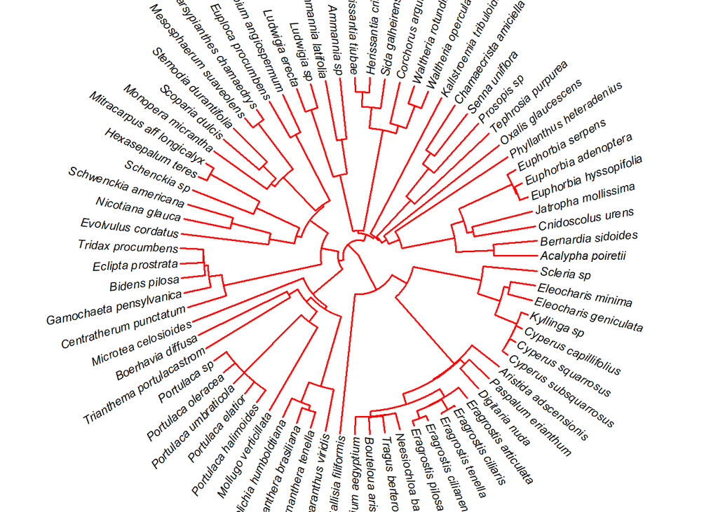

```r
plot(tree, type="fan", show.tip.label = TRUE,
            show.node.label = F, edge.color = "red", edge.width = 1.5,
            tip.color = "black", cex = 0.7, label.offset = 2, no.margin = T)
```

checar nomes

```r
cmm_p <- comunidade[,1:19]
setdiff(colnames(cmm), tree$tip.label)
```

```
## character(0)
```

Áreas (unidade amostral) nas linhas e espécies nas colunas (variável resposta).

```r
comunidade<- read.csv("comunidade2018.csv", h=T, ";", row.names=1)
comunidade_especies <- comunidade[,20:89]
```

Áreas (unidade amostral) nas linhas + métricas de paisagem nas coluna (variável preditoras: pd, ndvi) + tipo de intervencao.

```r
comunidade_preditoras <- comunidade[,1:19]
```

## MPD

quantificar a distância média do parentesco entre 2 espécies em uma comunidade.

```r
MPD <- mpd(comunidade_especies, cophenetic(tree),
           abundance.weighted = TRUE)
MPD<- as.data.frame(MPD)
rownames(MPD) <- rownames(comunidade)
MPD
```

```
##                MPD
## 3003     151.10130
## 3008     185.03271
## 3015     174.13113
## 3016     189.29240
## 3017     167.09122
## 3018      90.98123
## 3019     199.56851
## 3035     118.65269
## 3037     197.62496
## 3049     196.63501
## 3054     158.86018
## 3088     186.34515
## 4097     198.80094
## 4142     156.57963
## 4147     188.35349
## 4150     169.40965
## 4153     184.98275
## 4160     116.78326
## 4173     131.97877
## 4178     173.05147
## 4179     177.29558
## 4185     157.24084
## 4196     135.41868
## CAPTACAO  91.09705
## controle 213.17836
## junco    173.79540
## pousio1   41.84384
## pousio2  166.39516
## pousio3  193.08990
## pousio4  131.52111
## SALAO    198.34868
## uri      121.82507
```

## MNTD

quantificar a média de VALORES MÍNIMOS de parentesco entre 2 espécies em uma comunidade. qual o valor médio da distância para o vizinho mais próximo.

```r
MNTD <- mntd(comunidade_especies, cophenetic(tree),
             abundance.weighted = TRUE)
MNTD<- as.data.frame(MNTD)
rownames(MNTD) <- rownames(comunidade)
MNTD
```

```
##               MNTD
## 3003      76.07636
## 3008     146.11472
## 3015      66.73295
## 3016     105.74669
## 3017      61.59385
## 3018      23.91816
## 3019      85.57119
## 3035     132.21029
## 3037     115.58048
## 3049      59.64050
## 3054      69.57235
## 3088      56.45756
## 4097      90.87276
## 4142     111.28840
## 4147      73.33960
## 4150     126.58570
## 4153     116.32415
## 4160     143.78368
## 4173     122.98246
## 4178      50.67748
## 4179      47.10419
## 4185     164.09967
## 4196      63.27468
## CAPTACAO  30.80484
## controle 170.52030
## junco     84.37470
## pousio1   30.14051
## pousio2   81.69597
## pousio3   77.71533
## pousio4  131.30627
## SALAO     90.26534
## uri       57.29995
```

espécies terminais sao mais aparentadas na area 3018 e menos aparentadas no controle; (maior div. filo no controle como esperado(?))

```r
metricas_filogenetica <- data.frame(MPD = MPD,
                                   MNTD = MNTD)
metricas_filogenetica <- cbind(metricas_filogenetica, comunidade_preditoras)
```

# Hipótese 2 e 3

Áreas com maior cobertura vegetal possuem maior diversidade funcional, compreendendo uma sindrome funcional de atributos de plantas relacionados a especies mais especialistas.

Áreas com maior densidade de manchas possuem menor diversidade funcional, compreendendo uma síndrome funcional de atributos de plantas relacionados à espécies mais generalistas.

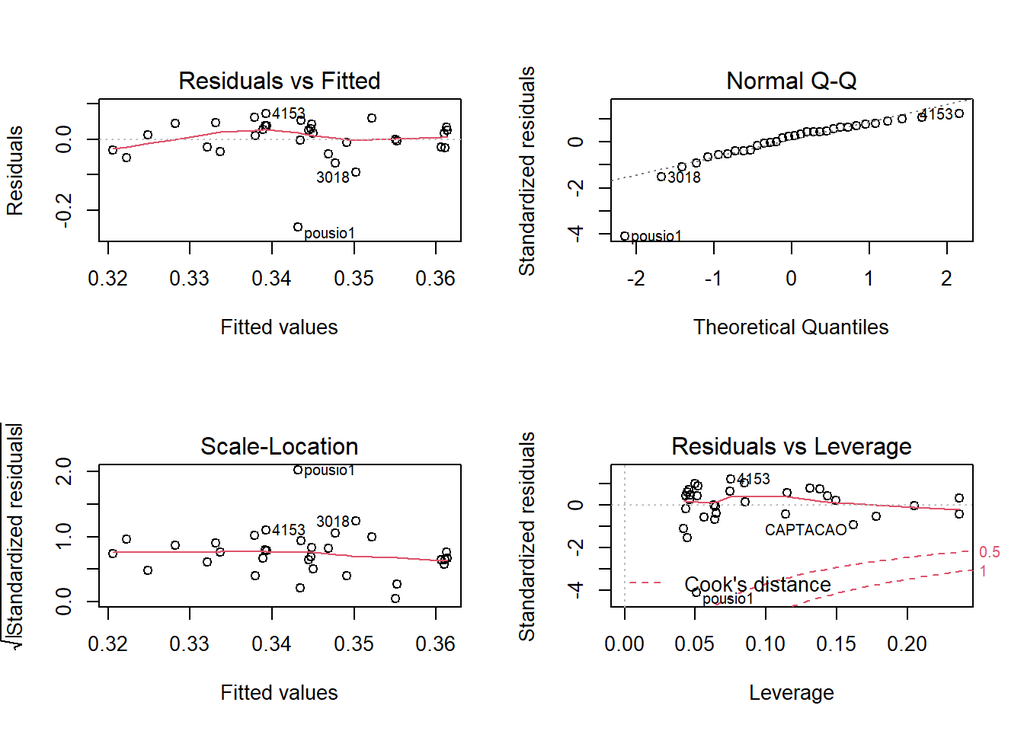

```r
dados <- cbind(metricas,comunidade)
model1 <- lm(fdis ~ ndv800+pd140, data=dados)
par(mfrow=c(2,2))
plot(model1)
```

```r
summary(model1)
```

```
##
## Call:
## lm(formula = fdis ~ ndv800 + pd140, data = dados)
##
## Residuals:
##      Min       1Q   Median       3Q      Max
## -0.24749 -0.02291  0.01451  0.03744  0.07236
##
## Coefficients:
##               Estimate Std. Error t value Pr(>|t|)
## (Intercept)  0.3434502  0.0280588  12.240 5.59e-13 ***
## ndv800       3.3199957  4.1857577   0.793    0.434
## pd140       -0.0007038  0.0008433  -0.835    0.411
## ---
## Signif. codes:  0 '***' 0.001 '**' 0.01 '*' 0.05 '.' 0.1 ' ' 1
##
## Residual standard error: 0.062 on 29 degrees of freedom
## Multiple R-squared:  0.03489,    Adjusted R-squared:  -0.03167
## F-statistic: 0.5242 on 2 and 29 DF,  p-value: 0.5975
```

#Hipótese 4 e 5 Áreas com maior cobertura vegetal possuem maior diversidade filogenética no banco de sementes.

Áreas com maior densidade de manchas possuem menor diversidade filogenética no banco de sementes.

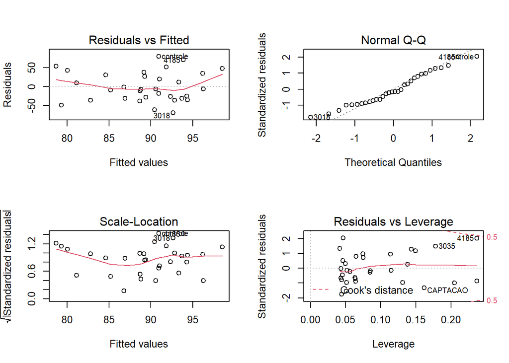

```r
dados <- cbind(dados, metricas_filogenetica)
dados <- dados[,1:98]
model2 <- lm(MNTD ~ ndv800+pd140, data=dados)
par(mfrow=c(2,2))
plot(model2)
```

```r
summary(model2)
```

```
##
## Call:
## lm(formula = MNTD ~ ndv800 + pd140, data = dados)
##
## Residuals:
##     Min      1Q  Median      3Q     Max
## -68.745 -30.422  -6.678  32.004  79.561
##
## Coefficients:
##              Estimate Std. Error t value Pr(>|t|)
## (Intercept)   92.8242    18.0920   5.131 1.76e-05 ***
## ndv800      1061.7343  2698.9250   0.393    0.697
## pd140         -0.3648     0.5437  -0.671    0.508
## ---
## Signif. codes:  0 '***' 0.001 '**' 0.01 '*' 0.05 '.' 0.1 ' ' 1
##
## Residual standard error: 39.98 on 29 degrees of freedom
## Multiple R-squared:  0.01695,    Adjusted R-squared:  -0.05085
## F-statistic:  0.25 on 2 and 29 DF,  p-value: 0.7805
```

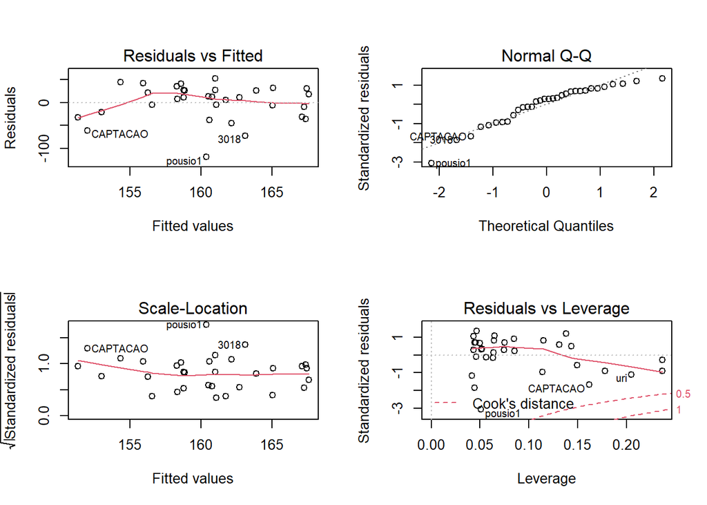

```r
model3 <- lm(MPD ~ ndv800+pd140, data=dados)
par(mfrow=c(2,2))
plot(model3)
```

```r
summary(model3)
```

```
##
## Call:
## lm(formula = MPD ~ ndv800 + pd140, data = dados)
##
## Residuals:
##     Min      1Q  Median      3Q     Max
## -118.52  -23.67   11.04   27.41   52.20
##
## Coefficients:
##              Estimate Std. Error t value Pr(>|t|)
## (Intercept)  160.5701    18.0303   8.906 8.55e-10 ***
## ndv800      1298.6413  2689.7188   0.483    0.633
## pd140         -0.2816     0.5419  -0.520    0.607
## ---
## Signif. codes:  0 '***' 0.001 '**' 0.01 '*' 0.05 '.' 0.1 ' ' 1
##
## Residual standard error: 39.84 on 29 degrees of freedom
## Multiple R-squared:  0.01354,    Adjusted R-squared:  -0.05449
## F-statistic: 0.1991 on 2 and 29 DF,  p-value: 0.8206
```

# REPETIR TUDO SEM ESPÉCIES EXÓTICAS

Dados sem exótica

```r
traits_SE<-read.csv("traits_2018_sem_exotica.csv", h=T, ";", row.names = 1)
comunidade_SE <- read.csv("comunidade2018_sem_exotica.csv", h=T, ";", row.names=1)
cmm_SE<-comunidade_SE[,20:75]
```

## PERGUNTA 1

Qual a sindrome funcional que prevalece?

```r
composicao_funcional_SE <- functcomp(x = traits_SE, a = as.matrix(cmm_SE), CWM.type = c("dom"))
paged_table(composicao_funcional_SE)
```

|  | h_max | h_min | leaf_min | leaf_max | semente | dispersal | life_span | type | Floral_rewarning | Pollination_systems | leaf_tipe | filotaxia | nativas |
| --- | --- | --- | --- | --- | --- | --- | --- | --- | --- | --- | --- | --- | --- |
| 3003 | 550.1147 | 124.83945 | 11.561927 | 92.05505 | 1.86895996 | autocoria | annual | erva | Nectar, polen | himenoptera | 0 | opostas | 0 |
| 3008 | 515.8152 | 185.65217 | 12.076087 | 95.56522 | 0.31317776 | autocoria | annual | erva | polen | himenoptera, diptera | 0 | verticilada | 0 |
| 3015 | 625.8999 | 140.79857 | 16.175309 | 87.26914 | 0.27848205 | autocoria | annual | erva | polen | wind | 0 | opostas | 0 |
| 3016 | 433.8856 | 105.52786 | 10.592375 | 91.82698 | 0.42222058 | autocoria | annual | erva | Nectar, polen | himenoptera | 0 | verticilada | 0 |
| 3017 | 703.8599 | 157.06745 | 16.361045 | 113.77910 | 2.49310753 | autocoria | annual | erva | polen | wind | 0 | verticilada | 0 |
| 3018 | 546.4058 | 156.66134 | 11.584665 | 128.67412 | 0.11745163 | autocoria | annual | erva | polen | lepdoptera | 0 | verticilada | 0 |
| 3019 | 303.7500 | 138.54167 | 13.458333 | 75.87500 | 0.27412713 | autocoria | annual | erva | polen | wind | 0 | opostas | 0 |
| 3035 | 282.7632 | 117.76316 | 15.131579 | 89.14474 | 0.26816996 | autocoria | annual | erva | polen | lepdoptera | 0 | alternas | 0 |
| 3037 | 382.4706 | 100.00000 | 11.517647 | 62.75294 | 0.99739463 | autocoria | annual | erva | Nectar | himenoptera | 0 | oposta | 0 |
| 3049 | 442.7778 | 104.72222 | 17.388889 | 128.27778 | 1.64243055 | autocoria | annual | erva | polen | lepdoptera | 0 | verticilada | 0 |

[output cut: 22 more lines]

## PERGUNTA 2

Como essas sindromes variam em funcao da condincao da paisagem?

função multifiti  
Pd: Densidade de manchas de floresta (por/hectare); medida de fragmentação da paisagem.  
NDV: Índice de Vegetação da Diferença Normalizada.

```
## The model including the effect 'ndv140' was the best model according to the specified criterion (AIC, which.min)
```

```
## Messages were found in the models with the following effects: ndv100, ndv140, ndv200, ndv280, ndv400, ndv560, ndv800, ndv1130
```

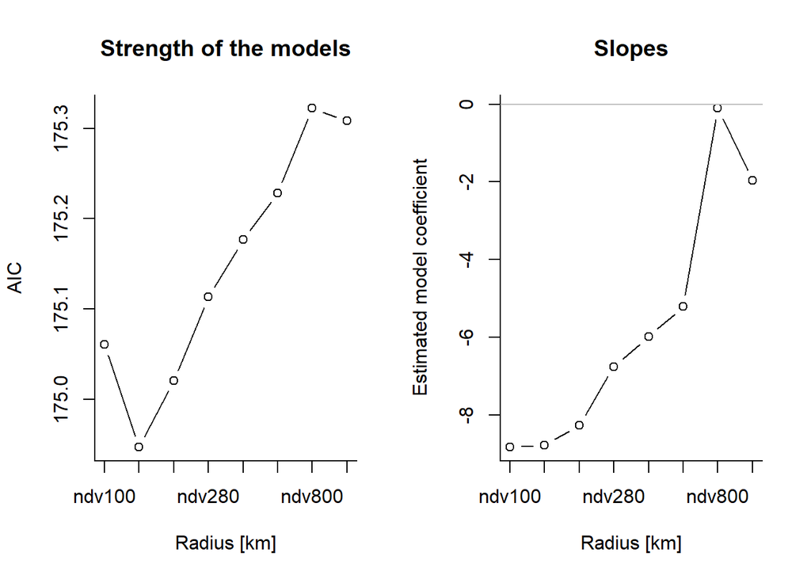

```r
comunidade_multfit_SE <- read.csv("comunidade2018_sem_exotica.csv", h=T, ";")
fits_ndv_SE <- multifit(mod="glmer", multief = colnames(comunidade_multfit_SE[4:11]),
                     formula=Riqueza~multief+(1|area), args=c("family=poisson"),data=comunidade_multfit_SE,
                     criterion = "AIC", plot_est = T)
```

```
## The model including the effect 'pd140' was the best model according to the specified criterion (AIC, which.min)
```

```
## Messages were found in the models with the following effects: pd100, pd140, pd200, pd280, pd400, pd560, pd800, pd1130
```

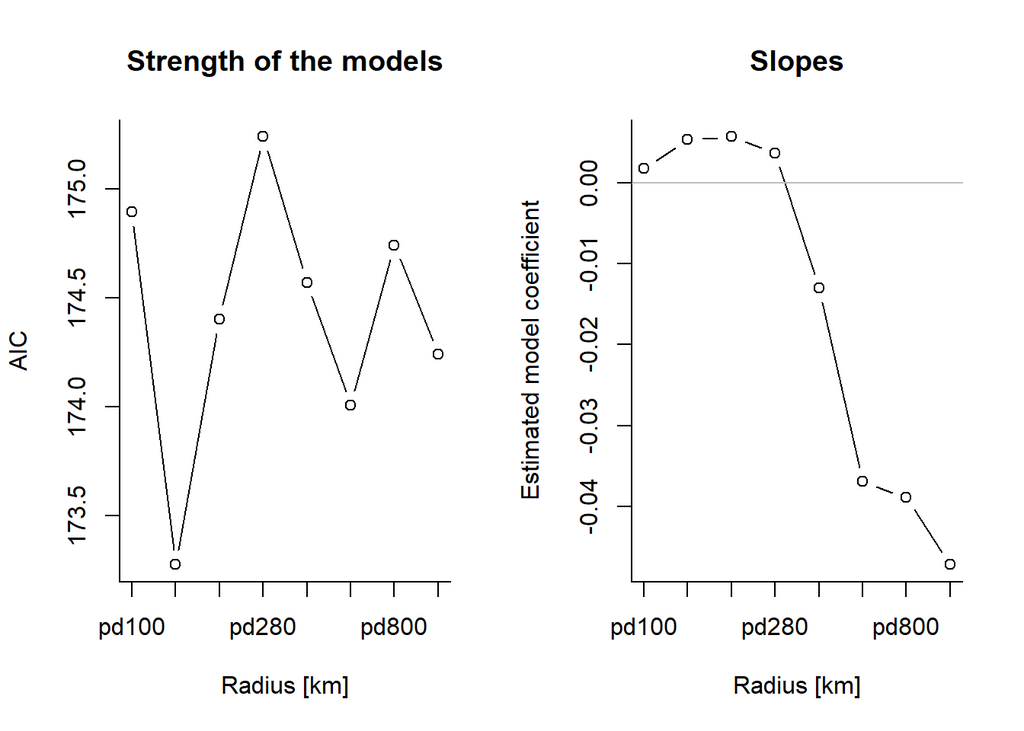

```r
fits_pd_SE <- multifit(mod="glmer", multief = colnames(comunidade_multfit_SE[12:19]),
                    formula=Riqueza~multief+(1|area), args=c("family=poisson"),data=comunidade_multfit_SE,
                    criterion = "AIC", plot_est = T)
```

funcional

```r
div.func_SE <- dbFD(x = traits_SE[,1:5], a = cmm_SE, corr = "lingoes", CWM.type = "all")
```

```
## Species x species distance matrix was not Euclidean. Lingoes correction was applied.
## FRic: Dimensionality reduction was required. The last 50 PCoA axes (out of 54 in total) were removed.
## FRic: Quality of the reduced-space representation (based on corrected distance matrix) = 0.2335698
```

## HIPÓTESE 2

areas com maior cobertura vegetal possuem maior diversidade funcional, compreendendo uma sindrome funcional de atributos de plantas relacionados a especies mais especialistas.

```r
model1_SE <- lm(FDis_SE ~ ndv800, data=dados_SE)
summary(model1_SE)
```

```
##
## Call:
## lm(formula = FDis_SE ~ ndv800, data = dados_SE)
##
## Residuals:
##       Min        1Q    Median        3Q       Max
## -0.095002 -0.020105  0.007564  0.019715  0.062515
##
## Coefficients:
##             Estimate Std. Error t value Pr(>|t|)
## (Intercept)  0.13053    0.01249  10.449 1.63e-11 ***
## ndv800      -1.02999    2.11328  -0.487     0.63
## ---
## Signif. codes:  0 '***' 0.001 '**' 0.01 '*' 0.05 '.' 0.1 ' ' 1
##
## Residual standard error: 0.03247 on 30 degrees of freedom
## Multiple R-squared:  0.007856,   Adjusted R-squared:  -0.02522
## F-statistic: 0.2375 on 1 and 30 DF,  p-value: 0.6295
```

## HIPÓTESE 3

Áreas com maior densidade de manchas possuem menor diversidade funcional, compreendendo uma síndrome funcional de atributos de plantas relacionados à espécies mais generalistas.

```r
model2_SE <- lm(FDis_SE ~ pd140, data=dados_SE)
summary(model2_SE)
```

```
##
## Call:
## lm(formula = FDis_SE ~ pd140, data = dados_SE)
##
## Residuals:
##       Min        1Q    Median        3Q       Max
## -0.097962 -0.013766  0.005033  0.019758  0.060717
##
## Coefficients:
##               Estimate Std. Error t value Pr(>|t|)
## (Intercept)  0.1401637  0.0115037  12.184 3.81e-13 ***
## pd140       -0.0006160  0.0004124  -1.494    0.146
## ---
## Signif. codes:  0 '***' 0.001 '**' 0.01 '*' 0.05 '.' 0.1 ' ' 1
##
## Residual standard error: 0.03144 on 30 degrees of freedom
## Multiple R-squared:  0.06922,    Adjusted R-squared:  0.0382
## F-statistic: 2.231 on 1 and 30 DF,  p-value: 0.1457
```

Diversidade Filogenética

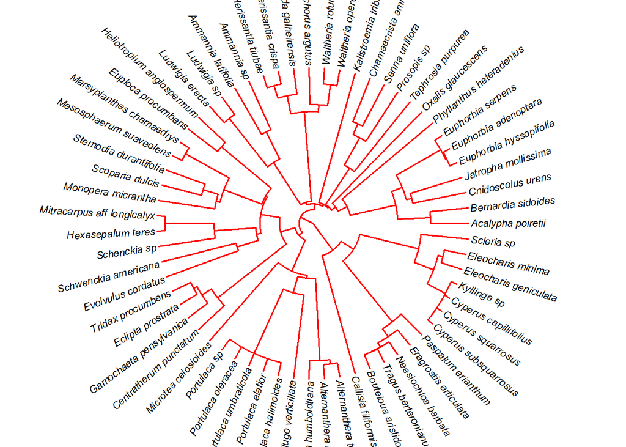

```r
tree <- read.tree("tree2018.tre")
tree_SE <- drop.tip(tree, c("Nicotiana_glauca", "Tridax_procumbens
", "Bidens_pilosa", "Boerhavia_diffusa", "Trianthema_portulacastrom", "
Portulaca_oleracea", "Amaranthus_viridis", "Dactyloctenium_aegyptium", "Eragrostis_pilosa", "Eragrostis_cilianensis", "Eragrostis_tenella", "Eragrostis_ciliaris", "Digitaria_nuda", "Aristida_adscensionis"))

plot(tree_SE, type="fan", show.tip.label = TRUE,
            show.node.label = F, edge.color = "red", edge.width = 1.5,
            tip.color = "black", cex = 0.7, label.offset = 2, no.margin = T)
```

checar nomes

```r
cmm_p <- comunidade_SE[,1:19]
setdiff(colnames(cmm_SE), tree_SE$tip.label)
```

```
## character(0)
```

Áreas (unidade amostral) nas linhas e espécies nas colunas (variável resposta).

```r
comunidade_SE<- read.csv("comunidade2018_sem_exotica.csv", h=T, ";", row.names=1)
names(comunidade_SE)
```

```
##  [1] "area_ha"                    "metodo"
##  [3] "ndv100"                     "ndv140"
##  [5] "ndv200"                     "ndv280"
##  [7] "ndv400"                     "ndv560"
##  [9] "ndv800"                     "ndv1130"
## [11] "pd100"                      "pd140"
## [13] "pd200"                      "pd280"
## [15] "pd400"                      "pd560"
## [17] "pd800"                      "pd1130"
## [19] "mod"                        "Acalypha_poiretii"
## [21] "Bernardia_sidoides"         "Cnidoscolus_urens"
## [23] "Jatropha_mollissima"        "Euphorbia_hyssopifolia"
## [25] "Euphorbia_adenoptera"       "Euphorbia_serpens"
## [27] "Phyllanthus_heteradenius"   "Oxalis_glaucescens"
## [29] "Tephrosia_purpurea"         "Senna_uniflora"
```

[output cut: 23 more lines]

```r
comunidade_especies_SE <- comunidade_SE[,20:75]
```

Áreas (unidade amostral) nas linhas + métricas de paisagem nas coluna (variável preditoras: pd, ndvi) + tipo de intervencao.

```r
comunidade_preditoras_SE <- comunidade_SE[,1:19]
```

MPD  
quantificar a distância média do parentesco entre 2 espécies em uma comunidade.

```r
MPD_SE <- mpd(comunidade_especies_SE, cophenetic(tree_SE),
           abundance.weighted = TRUE)
MPD_SE<- as.data.frame(MPD_SE)
rownames(MPD_SE) <- rownames(comunidade_SE)
MPD_SE
```

```
##             MPD_SE
## 3003     146.47445
## 3008     182.71793
## 3015     180.27582
## 3016     191.12922
## 3017     167.39522
## 3018     106.89232
## 3019     189.37229
## 3035     145.54484
## 3037     197.62496
## 3049     188.34267
## 3054     165.65290
## 3088     162.71519
## 4097     183.24202
## 4142     166.60421
## 4147     202.37626
## 4150     154.14093
## 4153     155.11455
## 4160     170.26757
## 4173     172.31698
## 4178     146.17030
## 4179     158.60912
## 4185     149.88243
## 4196     187.44428
## CAPTACAO  82.28613
## controle 201.22574
## junco    112.66907
## pousio1   39.05520
## pousio2  166.39516
## pousio3  177.94063
## pousio4  149.89016
## SALAO    208.07437
## uri      204.15991
```

MNTD  
quantificar a média de VALORES MÍNIMOS de parentesco entre 2 espécies em uma comunidade. qual o valor médio da distância para o vizinho mais próximo.

```r
MNTD_SE <- mntd(comunidade_especies_SE, cophenetic(tree_SE),
             abundance.weighted = TRUE)
MNTD_SE<- as.data.frame(MNTD_SE)
rownames(MNTD_SE) <- rownames(comunidade_SE)
MNTD_SE
```

```
##            MNTD_SE
## 3003      79.19509
## 3008      65.86879
## 3015      76.60136
## 3016      85.86391
## 3017      73.74453
## 3018      34.28502
## 3019      69.51104
## 3035      34.06042
## 3037     115.58048
## 3049      81.98834
## 3054      85.97771
## 3088      42.51832
## 4097      99.30225
## 4142      33.23880
## 4147      76.83236
## 4150      53.07034
## 4153      89.38190
## 4160      62.67385
## 4173      41.10015
## 4178      42.23698
## 4179      40.43992
## 4185     128.25702
## 4196     108.36855
## CAPTACAO  28.03106
## controle 246.71880
## junco     32.65479
## pousio1   29.95242
## pousio2   81.69597
## pousio3   66.12381
## pousio4  200.38421
## SALAO    102.61363
## uri       89.16630
```

```r
metricas_divergencia_SE <- data.frame(MPD_SE = MPD_SE,
                                   MNTD_SE = MNTD_SE)
metricas_divergencia_SE <- cbind(metricas_divergencia_SE, comunidade_preditoras_SE)
```

## HIPÓTESE 4

Áreas com maior cobertura vegetal possuem maior diversidade filogenética no banco de sementes.

## HIPÓTESE 5

Áreas com maior densidade de manchas possuem menor diversidade filogenética no banco de sementes.